# EA-IRMS Analysis of plant samples

Adrianne Seiden

2026-09-15

# Overview

This report analyzes the EA-IRMS data for plant samples, focusing on <sup>13</sup>C and <sup>15</sup>N isotopic enrichment in roots and aboveground tissues. The excel sheet file.path(box_base, “Salk Institute Project/AKS Salk files/EA_files/ea-data-for-R.xlsx”) contains EA-IRMS data from plant roots and aboveground biomass (sample-type = “roots” or sample-type = “aboveground”, respectively). Some of the plants were labeled with <sup>13</sup>C-enriched CO<sub>2</sub> during their V3 growth (isotope = “13C”). The plant materials come from 3 different crops: rice, wheat, and soy, plus no-plant controls (the “roots” from no-plant controls are root fragments that I picked out of the soil; they represent pre-existing soil organic matter rather than cultivated roots). The aboveground samples are all from T0 (i.e. the time when the aboveground biomass was removed, week = 0); the root samples may be from T0, 10 weeks of decomposition or 40 weeks of decomposition (week = 0, week = 10 or week = 40).This report produces the following figures:

1. A box plot comparing the <sup>13</sup>C atom-% of T0 roots from the 3 crops. The plot should include error bars, lines denoting the mean value for each crop and each individual data point.
2. The same box plot as above, using week 40 root data instead of week 0
3. A scatter plot showing <sup>13</sup>C vs %C (at T0), colored by crop, with shaded ovals enclosing the datapoints for each crop
4. The same scatterplot as above, showing <sup>13</sup>C vs <sup>15</sup>N
5. The same scatterplot as above, showing <sup>13</sup>C vs C:N ratio
6. A scatterplot showing <sup>13</sup>C of roots vs aboveground at T0 (each pot ID is a datapoint; only pots with T0 data for both roots and aboveground are included)
7. A scatterplot showing <sup>13</sup>C vs time, grouped by crop, including the best fit exponential trendline
8. The same scatterplot as above, but showing <sup>15</sup>N vs time
9. The same scatterplot as above, but showing C:N ratio vs time

# Setting up

This section sets up the environment, loads required libraries, and defines paths to data and output directories.

The hidden setup chunk configures knitr, installs any missing R packages, loads the shared visualization theme, defines crop labels, and creates the Box-based input and output paths. It is hidden from the rendered report because it prepares the analysis rather than producing a figure.

## Importing Data

This chunk reads the Excel workbook, renames columns with punctuation-heavy names to simpler analysis names, converts grouping variables to useful types, and keeps only enriched root samples for the root-focused figures. The original `ea_data` table remains available for the paired root/aboveground comparison.

```r
library(dplyr)  # Load data manipulation tools.
library(ggplot2)  # Load plotting tools.
library(readxl)  # Load Excel import tools.
library(tidyr)  # Load reshaping tools.

ea_data <- read_excel(file.path(data_folder, "ea-data-for-R.xlsx")) %>%
  rename(
    carbon13 = `13C (at-%)`,  # Rename the 13C measurement.
    nitrogen15 = `15N (at-%)`,  # Rename the 15N measurement.
    carbon_percent = `%C`,  # Rename percent carbon.
    sample_type = `sample-type`,  # Rename sample type.
    C_N = `C:N`  # Rename the C:N ratio.
  ) %>%
  mutate(
    crop = factor(crop, levels = c("soy", "rice", "wheat", "noPlant")),  # Set crop order.
    week = as.numeric(week),  # Convert week to numeric time.
    pot = as.character(pot)  # Treat pot IDs as labels.
  )

enriched_roots <- ea_data %>%
  filter(isotope == "13C", sample_type == "roots")  # Keep enriched roots only.

crop_levels <- c("soy", "rice", "wheat")  # Set the cultivated-crop order.
crop_labels <- c(soy = "Soy", rice = "Rice", wheat = "Wheat", noPlant = "No Plant")  # Define display labels.

plot_theme <-  theme(
    legend.position = "right",  # Keep the legend outside the panel.
    axis.title = element_text(size = 13, face = "bold"),  # Emphasize axis titles.
    axis.text = element_text(size = 12),  # Set readable axis text.
    panel.grid.minor = element_blank()  # Remove minor grid lines.
  )
```

# Box plots

## <sup>13</sup>C atom-% in Roots

This chunk creates the two requested root boxplots: one for T0 and one for week 40. Each plot includes the full distribution, individual observations, a mean marker, and a mean plus-or-minus one standard error bar for soy, rice, and wheat. The plots are displayed in the report and saved as themed PNG files.

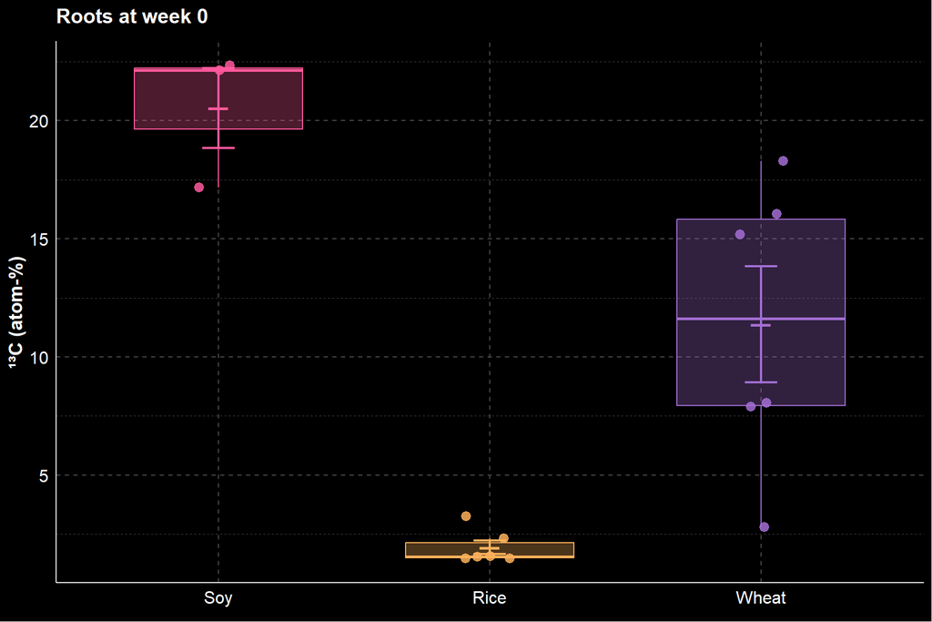

```r
root_summary <- enriched_roots %>%
  filter(crop %in% crop_levels, week %in% c(0, 40)) %>%  # Retain requested crops and weeks.
  group_by(crop, week) %>%  # Group by crop and decomposition week.
  summarise(
    mean_carbon13 = mean(carbon13, na.rm = TRUE),  # Calculate the group mean.
    se_carbon13 = sd(carbon13, na.rm = TRUE) / sqrt(sum(!is.na(carbon13))),  # Calculate the standard error.
    .groups = "drop"  # Return an ungrouped table.
  )

make_root_boxplot <- function(target_week) {
  plot_data <- enriched_roots %>%
    filter(crop %in% crop_levels, week == target_week) %>%  # Select the requested week.
    mutate(crop = factor(crop, levels = crop_levels))  # Preserve crop order.
  means <- root_summary %>% filter(week == target_week) %>%  # Select matching summaries.
    mutate(crop = factor(crop, levels = crop_levels))  # Preserve crop order.

  ggplot(plot_data, aes(x = crop, y = carbon13, fill = crop, color = crop)) +
    geom_boxplot(alpha = 0.30, width = 0.62, outlier.shape = NA) +  # Draw each crop's box.
    geom_jitter(width = 0.10, height = 0, size = 2.8, alpha = 0.85) +  # Show individual observations.
# Mean +/- SE error bars and mean markers for each crop.
    geom_errorbar(
      data = means,
        aes(x = crop, y = mean_carbon13, ymin = mean_carbon13 - se_carbon13,
          ymax = mean_carbon13 + se_carbon13),
      width = 0.12, linewidth = 0.8, color = crop_color[crop_levels],  # Draw mean +/- SE.
      inherit.aes = FALSE  # Use only the summary-layer mappings.
    ) +
    geom_point(
      data = means, aes(x = crop, y = mean_carbon13), shape = 95, size = 8,
      color = crop_color[crop_levels], inherit.aes = FALSE  # Mark the mean with a dash.
    ) +
    scale_x_discrete(labels = crop_labels[crop_levels]) +  # Use readable crop labels.
    scale_fill_manual(values = crop_color[crop_levels], guide = "none") +  # Color box fills.
    scale_color_manual(values = crop_color[crop_levels], guide = "none") +  # Color outlines and points.
    labs(x = element_blank(), y = "¹³C (atom-%)", title = paste("Roots at week", target_week)) +  # Label the figure.
    plot_theme  # Apply common styling.
}

root_boxplot_t0 <- make_root_boxplot(0)  # Build the T0 boxplot.
root_boxplot_t0  # Display the T0 boxplot.
```

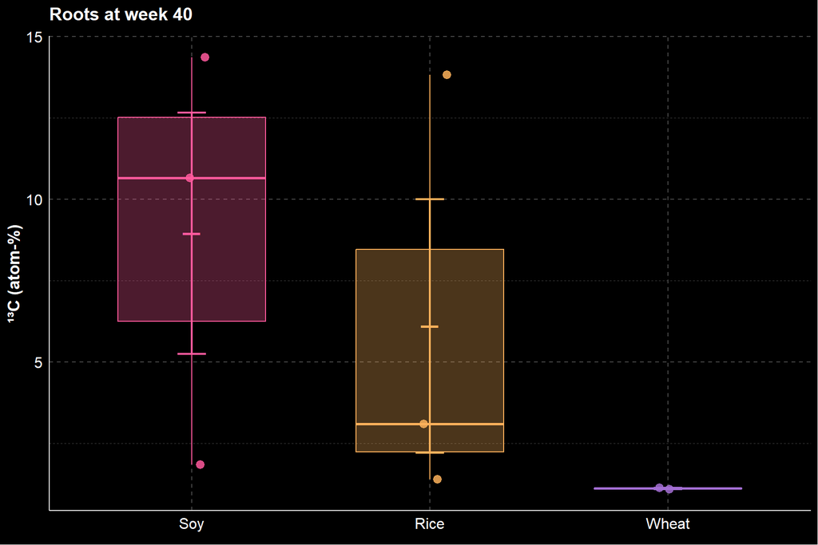

```r
ggsave_themed("EA_root_13C_at_percent_T0.png", root_boxplot_t0, width = 9, height = 6)  # Save T0 output.

root_boxplot_wk40 <- make_root_boxplot(40)  # Build the week-40 boxplot.
root_boxplot_wk40  # Display the week-40 boxplot.
```

```r
ggsave_themed("EA_root_13C_at_percent_week40.png", root_boxplot_wk40, width = 9, height = 6)  # Save output.
```

# Initial root composition scatterplots

## <sup>13</sup>C and Root Elemental Composition at T0

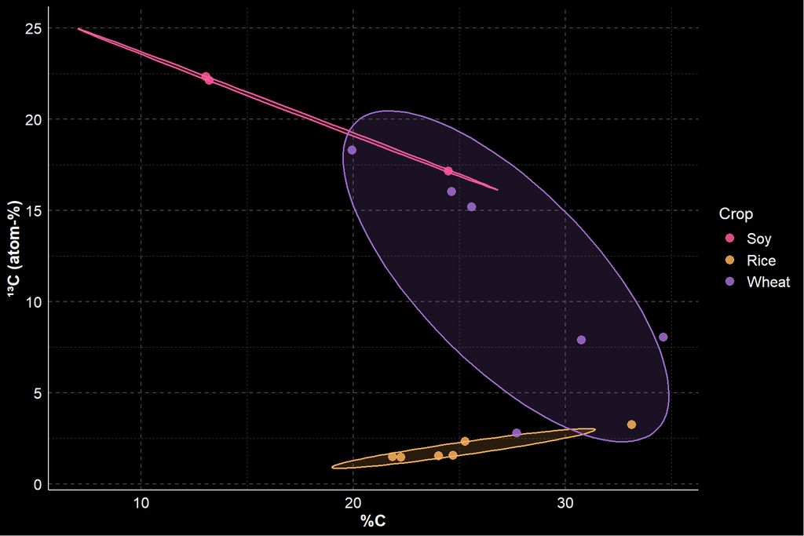

```r
root_t0 <- enriched_roots %>%
  filter(crop %in% crop_levels, week == 0) %>%  # Keep cultivated T0 roots.
  mutate(crop = factor(crop, levels = crop_levels))  # Preserve crop order.

make_covariance_ellipses <- function(data, x_variable, level = 0.68, n_points = 100) {
  data %>%
    group_by(crop) %>%  # Calculate an ellipse independently for each crop.
    group_modify(~ {
      coordinates <- cbind(.x[[x_variable]], .x$carbon13)  # Combine x and 13C coordinates.
      center <- colMeans(coordinates, na.rm = TRUE)  # Find the point-cloud center.
      covariance <- cov(coordinates, use = "complete.obs")  # Estimate the covariance matrix.
      eigen_covariance <- eigen(covariance, symmetric = TRUE)  # Decompose covariance for rotation and scale.
      eigen_covariance$values <- pmax(eigen_covariance$values, .Machine$double.eps)  # Prevent zero-eigenvalue issues.
      angles <- seq(0, 2 * pi, length.out = n_points)  # Generate points around a circle.
      radius <- sqrt(qchisq(level, df = 2))  # Convert the probability level to a radius.
      ellipse <- t(center + radius * eigen_covariance$vectors %*%
        diag(sqrt(eigen_covariance$values), nrow = 2) %*%
        rbind(cos(angles), sin(angles)))
      tibble(x_value = ellipse[, 1], carbon13 = ellipse[, 2])  # Return tidy ellipse coordinates.
    }) %>%
    ungroup()  # Remove temporary grouping.
}

make_composition_plot <- function(x_variable, x_label, file_name) {
  ellipse_data <- make_covariance_ellipses(root_t0, x_variable)  # Calculate crop-specific ellipses.
  p <- ggplot(root_t0, aes(x = .data[[x_variable]], y = carbon13, color = crop, fill = crop)) +
    geom_polygon(
      data = ellipse_data,
      aes(x = x_value, y = carbon13, group = crop, fill = crop),
      color = NA, alpha = 0.16, inherit.aes = FALSE, show.legend = FALSE  # Fill each crop's ellipse.
    ) +
    geom_path(
      data = ellipse_data,
      aes(x = x_value, y = carbon13, group = crop, color = crop),
      linewidth = 0.7, inherit.aes = FALSE, show.legend = FALSE  # Outline each ellipse.
    ) +
    geom_point(size = 3, alpha = 0.85) +  # Overlay individual root measurements.
    scale_color_manual(values = crop_color[crop_levels], labels = crop_labels[crop_levels]) +  # Set point colors.
    scale_fill_manual(values = crop_color[crop_levels], guide = "none") +  # Set ellipse fills.
    labs(x = x_label, y = "¹³C (atom-%)", color = "Crop") +  # Label axes and legend.
    plot_theme  # Apply common styling.
  print(p)
  ggsave_themed(file_name, p, width = 9, height = 6)  # Save the themed PNG.
  p  # Return the plot object.
}

root_13c_vs_carbon <- make_composition_plot(
  "carbon_percent", "%C", "EA_root_13C_vs_percent_C_T0.png"
)
```

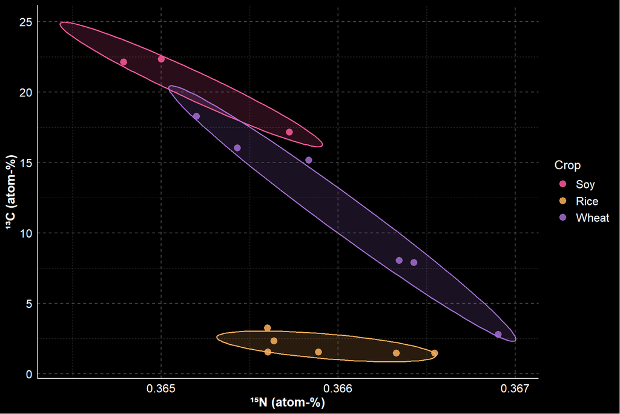

```r
root_13c_vs_nitrogen <- make_composition_plot(
  "nitrogen15", "¹⁵N (atom-%)", "EA_root_13C_vs_15N_T0.png"
)
```

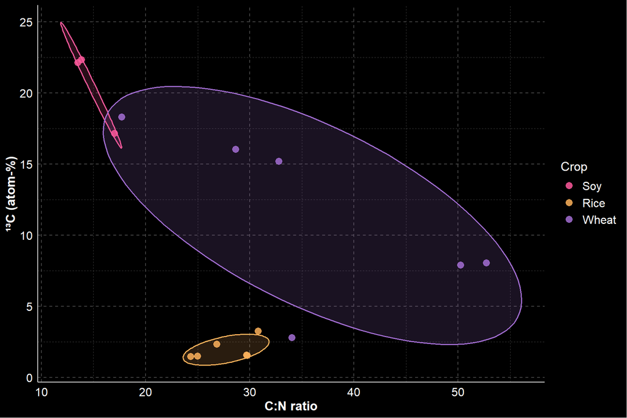

```r
root_13c_vs_CN <- make_composition_plot(
  "C_N", "C:N ratio", "EA_root_13C_vs_CN_T0.png"
)
```

## Paired Root and Aboveground <sup>13</sup>C at T0

This chunk compares enriched root and aboveground <sup>13</sup>C at T0 for the nine specified pots. Duplicate analytical rows within a pot and sample type are averaged first, then the data are widened so each pot contributes one root/aboveground point. The dashed one-to-one line provides a visual reference for equal enrichment in the two plant compartments.

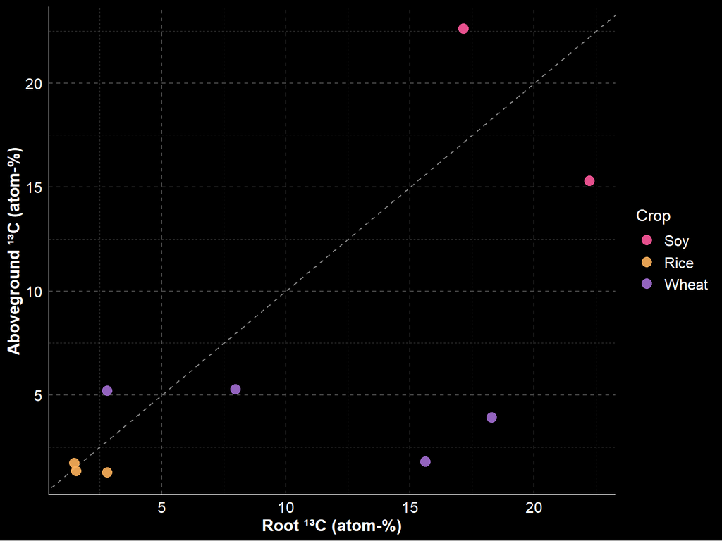

```r
paired_pots <- c("62", "50", "53", "32", "24", "1", "103", "79", "47")  # Identify complete-pair pots.

paired_data <- ea_data %>%
  filter(
    isotope == "13C", week == 0, pot %in% paired_pots,
    sample_type %in% c("roots", "aboveground")
  ) %>%
  group_by(pot, crop, sample_type) %>%  # Group replicate analytical rows.
  summarise(carbon13 = mean(carbon13, na.rm = TRUE), .groups = "drop") %>%  # Average replicates.
  pivot_wider(names_from = sample_type, values_from = carbon13) %>%  # Separate roots and aboveground columns.
  drop_na(roots, aboveground) %>%  # Keep complete pairs only.
  mutate(crop = factor(crop, levels = crop_levels))  # Preserve crop order.

paired_plot <- ggplot(paired_data, aes(x = roots, y = aboveground, color = crop)) +
  geom_abline(slope = 1, intercept = 0, linetype = "dashed", color = annotation_line_color) +  # Add equality line.
  geom_point(size = 3.5, alpha = 0.9) +  # Plot one point per pot.
  scale_color_manual(values = crop_color[crop_levels], labels = crop_labels[crop_levels]) +  # Set crop colors.
  labs(x = "Root ¹³C (atom-%)", y = "Aboveground ¹³C (atom-%)", color = "Crop") +  # Label the figure.
  plot_theme  # Apply common styling.

paired_plot  # Display the paired plot.
```

```r
ggsave_themed("EA_root_vs_aboveground_13C_T0.png", paired_plot, width = 8, height = 6)  # Save the plot.
```

# Trends over time

## <sup>13</sup>C Through Decomposition

This chunk shows enriched root <sup>13</sup>C over decomposition time for soy, rice, and wheat, with no-plant controls excluded. It fits the exponential model `asymptote + amplitude * exp(rate * week)` independently within each crop. The fitted models are evaluated on a shared sequence of weeks so the resulting crop-specific trendlines can be drawn together with the observations.

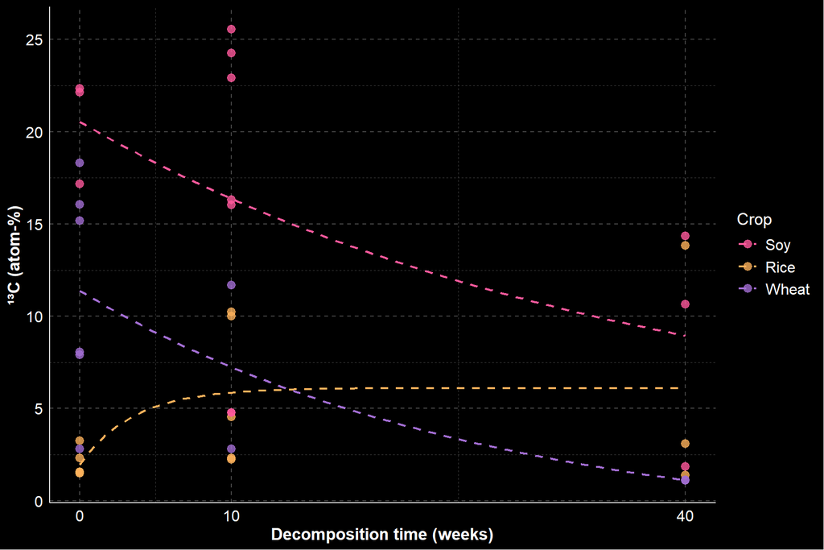

```r
trend_data <- enriched_roots %>%
  filter(crop %in% crop_levels) %>%  # Exclude no-plant controls.
  mutate(crop = factor(crop, levels = crop_levels))  # Preserve crop order.

fit_exponential <- function(data) {
  data <- data %>% filter(is.finite(carbon13), is.finite(week))  # Remove invalid values.
  if (nrow(data) < 3 || n_distinct(data$week) < 2) return(NULL)  # Require enough data for a fit.

  week_means <- data %>%
    group_by(week) %>%  # Group observations by time.
    summarise(mean_carbon13 = mean(carbon13), .groups = "drop") %>%  # Calculate timepoint means.
    arrange(week)  # Sort means chronologically.

  tryCatch(
    nls(carbon13 ~ asymptote + amplitude * exp(rate * week), data = data,
        start = list(
          asymptote = tail(week_means$mean_carbon13, 1),  # Start at the final mean.
          amplitude = head(week_means$mean_carbon13, 1) - tail(week_means$mean_carbon13, 1),  # Start with endpoint difference.
          rate = -0.02  # Start with a decreasing exponential rate.
        )),
    error = function(e) NULL  # Return NULL if this crop cannot be fitted.
  )
}

trend_fits <- trend_data %>%
  group_by(crop) %>%  # Fit one independent model per crop.
  group_modify(~ tibble(model = list(fit_exponential(.x)))) %>%  # Store each model in a list-column.
  ungroup() %>%  # Remove grouping after fitting.
  filter(!vapply(model, is.null, logical(1)))  # Keep successful fits only.

trend_lines <- do.call(rbind, lapply(seq_len(nrow(trend_fits)), function(index) {
  prediction_weeks <- seq(
    min(trend_data$week, na.rm = TRUE),
    max(trend_data$week, na.rm = TRUE),
    length.out = 100  # Use a shared 0-to-40-week prediction range.
  )
  data.frame(
    crop = trend_fits$crop[index],  # Preserve the crop identity.
    week = prediction_weeks,  # Store the prediction times.
    carbon13 = predict(
      trend_fits$model[[index]],
      newdata = data.frame(week = prediction_weeks)
    )  # Evaluate the current crop's fitted model.
  )
}))

trend_plot <- ggplot(trend_data, aes(x = week, y = carbon13, color = crop)) +
  geom_point(size = 2.8, alpha = 0.80) +  # Show individual root measurements.
  geom_line(data = trend_lines, aes(group = crop), linewidth = 0.75, linetype = "dashed") +  # Draw crop curves.
  scale_color_manual(
    values = crop_color[crop_levels],
    labels = crop_labels[crop_levels]  # Apply shared crop colors and labels.
  ) +
  scale_x_continuous(breaks = c(0, 10, 40)) +  # Mark observed decomposition weeks.
  labs(x = "Decomposition time (weeks)", y = "¹³C (atom-%)", color = "Crop") +  # Label axes and legend.
  plot_theme  # Apply common styling.

trend_plot  # Display the time-course plot.
```

```r
ggsave_themed("EA_root_13C_exponential_by_week.png", trend_plot, width = 9, height = 6)  # Save the figure.
```

## <sup>15</sup>N Through Decomposition

This chunk shows root <sup>15</sup>N over decomposition time for soy, rice, and wheat, with no-plant controls excluded. It fits the exponential model `asymptote + amplitude * exp(rate * week)` independently within each crop. The fitted models are evaluated on a shared sequence of weeks so the resulting crop-specific trendlines can be drawn together with the observations.

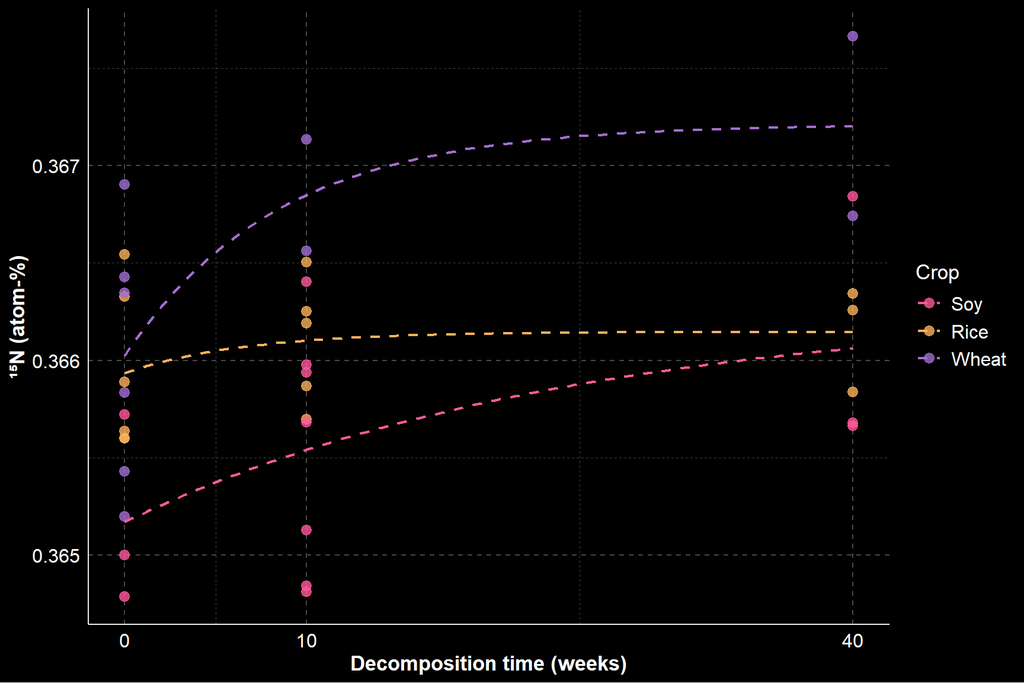

```r
trend_data <- enriched_roots %>%
  filter(crop %in% crop_levels) %>%  # Exclude no-plant controls.
  mutate(crop = factor(crop, levels = crop_levels))  # Preserve crop order.

fit_exponential <- function(data) {
  data <- data %>% filter(is.finite(nitrogen15), is.finite(week))  # Remove invalid values.
  if (nrow(data) < 3 || n_distinct(data$week) < 2) return(NULL)  # Require enough data for a fit.

  week_means <- data %>%
    group_by(week) %>%  # Group observations by time.
    summarise(mean_nitrogen15 = mean(nitrogen15), .groups = "drop") %>%  # Calculate timepoint means.
    arrange(week)  # Sort means chronologically.

  tryCatch(
    nls(nitrogen15 ~ asymptote + amplitude * exp(rate * week), data = data,
        start = list(
          asymptote = tail(week_means$mean_nitrogen15, 1),  # Start at the final mean.
          amplitude = head(week_means$mean_nitrogen15, 1) - tail(week_means$mean_nitrogen15, 1),  # Start with endpoint difference.
          rate = -0.02  # Start with a decreasing exponential rate.
        )),
    error = function(e) NULL  # Return NULL if this crop cannot be fitted.
  )
}

trend_fits <- trend_data %>%
  group_by(crop) %>%  # Fit one independent model per crop.
  group_modify(~ tibble(model = list(fit_exponential(.x)))) %>%  # Store each model in a list-column.
  ungroup() %>%  # Remove grouping after fitting.
  filter(!vapply(model, is.null, logical(1)))  # Keep successful fits only.

trend_lines <- do.call(rbind, lapply(seq_len(nrow(trend_fits)), function(index) {
  prediction_weeks <- seq(
    min(trend_data$week, na.rm = TRUE),
    max(trend_data$week, na.rm = TRUE),
    length.out = 100  # Use a shared 0-to-40-week prediction range.
  )
  data.frame(
    crop = trend_fits$crop[index],  # Preserve the crop identity.
    week = prediction_weeks,  # Store the prediction times.
    nitrogen15 = predict(
      trend_fits$model[[index]],
      newdata = data.frame(week = prediction_weeks)
    )  # Evaluate the current crop's fitted model.
  )
}))

trend_plot <- ggplot(trend_data, aes(x = week, y = nitrogen15, color = crop)) +
  geom_point(size = 2.8, alpha = 0.80) +  # Show individual root measurements.
  geom_line(data = trend_lines, aes(group = crop), linewidth = 0.75, linetype = "dashed") +  # Draw crop curves.
  scale_color_manual(
    values = crop_color[crop_levels],
    labels = crop_labels[crop_levels]  # Apply shared crop colors and labels.
  ) +
  scale_x_continuous(breaks = c(0, 10, 40)) +  # Mark observed decomposition weeks.
  labs(x = "Decomposition time (weeks)", y = "¹⁵N (atom-%)", color = "Crop") +  # Label axes and legend.
  plot_theme  # Apply common styling.

trend_plot  # Display the time-course plot.
```

```r
ggsave_themed("EA_root_15N_exponential_by_week.png", trend_plot, width = 9, height = 6)  # Save the figure.
```

## C:N Through Decomposition

This chunk shows root C:N ratios over decomposition time for soy, rice, and wheat, with no-plant controls excluded. It fits the exponential model `asymptote + amplitude * exp(rate * week)` independently within each crop. The fitted models are evaluated on a shared sequence of weeks so the resulting crop-specific trendlines can be drawn together with the observations.

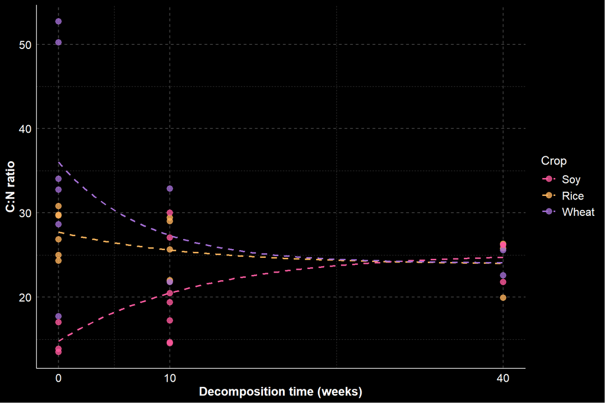

```r
trend_data <- enriched_roots %>%
  filter(crop %in% crop_levels) %>%  # Exclude no-plant controls.
  mutate(crop = factor(crop, levels = crop_levels))  # Preserve crop order.

fit_exponential <- function(data) {
  data <- data %>% filter(is.finite(C_N), is.finite(week))  # Remove invalid values.
  if (nrow(data) < 3 || n_distinct(data$week) < 2) return(NULL)  # Require enough data for a fit.

  week_means <- data %>%
    group_by(week) %>%  # Group observations by time.
    summarise(mean_cn = mean(C_N), .groups = "drop") %>%  # Calculate timepoint means.
    arrange(week)  # Sort means chronologically.

  tryCatch(
    nls(C_N ~ asymptote + amplitude * exp(rate * week), data = data,
        start = list(
          asymptote = tail(week_means$mean_cn, 1),  # Start at the final mean.
          amplitude = head(week_means$mean_cn, 1) - tail(week_means$mean_cn, 1),  # Start with endpoint difference.
          rate = -0.02  # Start with a decreasing exponential rate.
        )),
    error = function(e) NULL  # Return NULL if this crop cannot be fitted.
  )
}

trend_fits <- trend_data %>%
  group_by(crop) %>%  # Fit one independent model per crop.
  group_modify(~ tibble(model = list(fit_exponential(.x)))) %>%  # Store each model in a list-column.
  ungroup() %>%  # Remove grouping after fitting.
  filter(!vapply(model, is.null, logical(1)))  # Keep successful fits only.

trend_lines <- do.call(rbind, lapply(seq_len(nrow(trend_fits)), function(index) {
  prediction_weeks <- seq(
    min(trend_data$week, na.rm = TRUE),
    max(trend_data$week, na.rm = TRUE),
    length.out = 100  # Use a shared 0-to-40-week prediction range.
  )
  data.frame(
    crop = trend_fits$crop[index],  # Preserve the crop identity.
    week = prediction_weeks,  # Store the prediction times.
    C_N = predict(
      trend_fits$model[[index]],
      newdata = data.frame(week = prediction_weeks)
    )  # Evaluate the current crop's fitted model.
  )
}))

trend_plot <- ggplot(trend_data, aes(x = week, y = C_N, color = crop)) +
  geom_point(size = 2.8, alpha = 0.80) +  # Show individual root measurements.
  geom_line(data = trend_lines, aes(group = crop), linewidth = 0.75, linetype = "dashed") +  # Draw crop curves.
  scale_color_manual(
    values = crop_color[crop_levels],
    labels = crop_labels[crop_levels]  # Apply shared crop colors and labels.
  ) +
  scale_x_continuous(breaks = c(0, 10, 40)) +  # Mark observed decomposition weeks.
  labs(x = "Decomposition time (weeks)", y = "C:N ratio", color = "Crop") +  # Label axes and legend.
  plot_theme  # Apply common styling.

trend_plot  # Display the time-course plot.
```

```r
ggsave_themed("EA_root_CN_exponential_by_week.png", trend_plot, width = 9, height = 6)  # Save the figure.
```